# Property Increases

Zoe Iacovino

2022-07-19

```r
library(tidycensus)
library(tidyverse)
options(tigris_use_cache = TRUE)
library(ggplot2)
library(ggthemes)
library(sf)
library(biscale)
library(cowplot)
library(leaflet)
library(htmltools)
library(htmlwidgets)
library(foreign)
library(readr)
library(sp)
library(spdplyr)
library(rgdal)
library(maps)
library(spatialEco)
library(interactions)
library(broom)
library(nngeo)



lat_lon_CRS <- "+proj=longlat +ellps=WGS84 +datum=WGS84 +no_defs"
MA_state_plane <- "+proj=lcc +lat_1=41.71666666666667 +lat_2=42.68333333333333 +lat_0=41 +lon_0=-71.5 +x_0=200000 +y_0=750000 +ellps=GRS80 +units=m +no_defs"

WGS84 <- "+proj=longlat +ellps=WGS84 +datum=WGS84 +no_defs"
```

# Predicting Risk of Displacement from Rising Property Values

## GLX and Existing Station Walksheds

```r
wkshds10<-st_read("Polygons.shp")%>%
  filter(ToBreak == 10,
         Name != "Relocated Lechmere Station : 0 - 10")%>%
  subset(select = c(Name, geometry))%>%
  mutate(glx10 = TRUE)%>%
  st_union()
```

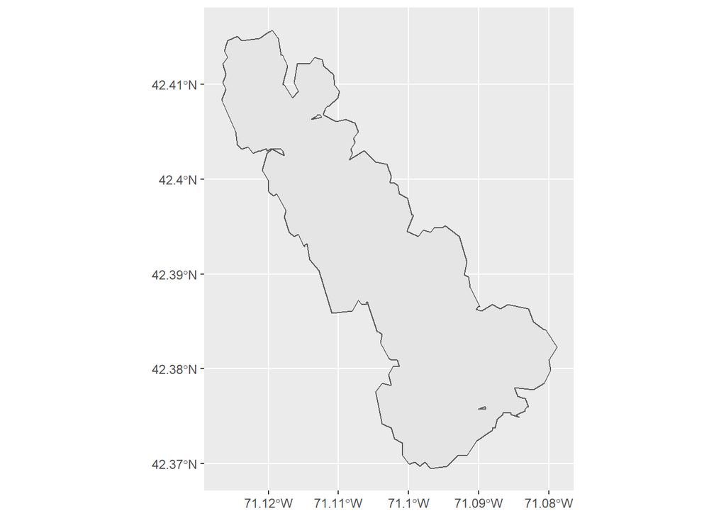

```r
ggplot(wkshds10) +
  geom_sf()
```

```r
wkshds20<-st_read("Polygons.shp")%>%
  filter(ToBreak == 20,
         Name != "Relocated Lechmere Station : 10 - 20")%>%
  subset(select = c(Name, geometry))%>%
  mutate(glx20 = TRUE)%>%
  st_union()
```

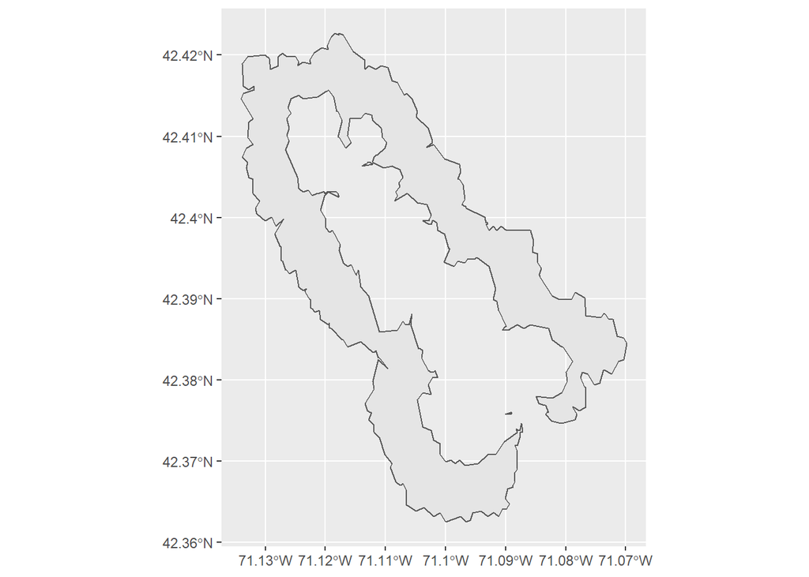

```r
ggplot(wkshds20) +
  geom_sf()
```

```r
rl_ws10<-st_read("Red Line Walkshed.shp")%>%
   filter(ToBreak == 10)%>%
  #subset(select = geometry)%>%
  mutate(exsys10 = TRUE)
rl_ws20<-st_read("Red Line Walkshed.shp")%>%
   filter(ToBreak == 20)%>%
  #subset(select = geometry)%>%
  mutate(exsys20 = TRUE)
ol_ws10<-st_read("Orange Line Walkshed.shp")%>%
   filter(ToBreak == 10)%>%
  #subset(select = geometry)%>%
  mutate(exsys10 = TRUE)
ol_ws20<-st_read("Orange Line Walkshed.shp")%>%
   filter(ToBreak == 20)%>%
  #subset(select = geometry)%>%
  mutate(exsys20 = TRUE)
somexsys10 <- rbind(rl_ws10, ol_ws10)%>%
  st_union()
somexsys20 <- rbind(rl_ws20, ol_ws20)%>%
  st_union()
```

## Somerville Assessed Property Data

```r
pardata <- read.dbf("M274Assess_CY21_FY21.dbf")%>%
  mutate(STYLE = case_when(
                STYLE == "2-Decker" ~ "Two-Family",
                STYLE == "Store" ~ "Commercial",
                STYLE == "Two decker" ~ "Two-Family",
                STYLE == "Condominium" ~  "Condominium",
                STYLE == "Outbuildings" ~ "???",
                STYLE == "Two Family" ~ "Two-Family",
                STYLE == "Other State" ~ "???",
                STYLE == "Warehouse" ~ "Commercial",
                STYLE == "2 Fam Conv" ~ "Two-Family",
                STYLE == "Other Municip" ~ "???",
                STYLE == "Vacant Land" ~ "Vacant",
                STYLE == "3 fam Conv" ~ "Triple Decker",
                STYLE == "Auto Sales Rpr" ~ "Commercial",
                STYLE == "Row End" ~ "Apartment",
                STYLE == "Row Middle" ~ "Apartment",
                STYLE == "Serv Sta 2-bay" ~ "Commercial",
                STYLE == "Conventional" ~ "???",
                STYLE == "Cottage Bungalow" ~ "Single-Family",
                STYLE == "Condo Office" ~ "Commercial",
                STYLE == "Low rise" ~ "Apartment",
                STYLE == "Retail Condo" ~ "Commercial",
                STYLE == "Three decker" ~ "Triple Decker",
                STYLE == "3-Decker" ~ "Triple Decker",
                STYLE == "Office Bldg" ~ "Commercial",
                STYLE == "3-Decker-Apts" ~  "Apartment",
                STYLE == "Mansard" ~ "Single-Family",
                STYLE == "Fam Conv" ~ "Single-Family",
                STYLE == "Conventional-Apts" ~ "Apartment",
                STYLE == "Townhouse end" ~ "Condominium",
                STYLE == "Stores/Apt Com" ~ "Commercial",
                STYLE == "Apartments" ~ "Apartment",
                STYLE == "Townhouse middle" ~ "Condominium",
                STYLE == "Family Duplex-Apts" ~ "Two-Family",
                STYLE == "Duplex" ~ "Two-Family",
                STYLE == "Funeral Home" ~ "Commercial",
                STYLE == "Mid Rise Apartments" ~ "Apartment",
                STYLE == "Churches" ~ "Other",
                STYLE == "Library" ~ "Other",
                STYLE == "Office/Apts" ~ "Mixed Use",
                STYLE == "Victorian" ~ "Single-Family",
                STYLE == "Family Duplex" ~ "Two-Family",
                STYLE == "Light Indust" ~ "Industrial",
                STYLE == "2-Decker-Apts" ~ "Apartment",
                STYLE == "Two Family-Apts" ~ "Apartment",
                STYLE == "Branch Bank" ~ "Other",
                STYLE == "Child Care" ~ "Commercial",
                STYLE == "Dry Cln/Laundr" ~ "Commercial",
                STYLE == "Townhouse" ~ "Condominium",
                STYLE == "Retail/Offices" ~ "Commercial",
                STYLE == "Restaurant" ~ "Commercial",
                STYLE == "Profess. Bldg" ~ "???",
                STYLE == "Mid rise" ~ "Apartment",
                STYLE == "Double 3D"~ "Double Triple",
                STYLE == "Convert Warehs/Loft" ~ "Apartment",
                STYLE == "School/College" ~ "Other",
                STYLE == "High End Constr" ~ "???",
                STYLE == "Mansard-Apts" ~ "Apartment",
                STYLE == "Schools-Public" ~ "Other",
                STYLE == "Clubs/Lodges" ~ "Other",
                STYLE == "Supermarket" ~ "Supermarket",
                STYLE == "Colleges" ~ "Other",
                STYLE == "Dormitory" ~ "Dormitory",
                STYLE == "Service Shop" ~ "Commercial",
                STYLE == "Cottage" ~ "Single-Family",
                STYLE == "Row Mid" ~ "Apartment",
                STYLE == "High Rise Apt" ~ "Apartment",
                STYLE == "Fire Station" ~ "Other",
                STYLE == "Finan Inst." ~ "Other",
                STYLE == "Bakery" ~ "Commercial",
                STYLE == "Stores/Office" ~ "Commercial",
                STYLE == "Row Mid-Apts" ~ "Apartment",
                STYLE == "Row End-Apts" ~ "Apartment",
                STYLE == "Fast Food Rest" ~ "Commercial",
                STYLE == "Office/Warehs" ~ "Commercial",
                STYLE == "Home for Aged" ~ "Senior Living",
                STYLE == "Converted School" ~ "Other",
                STYLE == "Theaters Encl." ~ "Commercial",
                STYLE == "Other Federal" ~ "Other",
                STYLE == "Department Str" ~ "Commercial",
                STYLE == "Nightclub/Bar" ~ "Commercial",
                STYLE == "Hospital" ~ "Other",
                STYLE == "Hotel" ~ "Commercial",
                STYLE == "Commercial" ~ "Commercial",
                STYLE == "Skating Arena" ~ "Other",
                STYLE == "Serv Sta 3-Bay" ~ "Commercial",
                STYLE == "Garage/Office" ~ "Commercial",
                STYLE == "City/Town Hall" ~ "Other",
                STYLE == "Truck Terminal" ~ "Commercial",
                STYLE == "Food Process" ~ "Commercial",
                STYLE == "Comm Warehouse" ~ "Commercial",
                STYLE == "Commercial Bld" ~ "Commercial",
                STYLE == "Health Club/Gym" ~ "Commercial",
                STYLE == "Converted Municipal" ~ "Other",
                STYLE == "Research/Devel" ~ "Other",
                STYLE == "Car Wash" ~ "Commercial",
                STYLE == "Hospitals-Priv" ~ "Other",
                STYLE == "Victorian-Apts" ~ "Apartment",
                STYLE == "Coin-op CarWsh" ~ "Commercial",
                STYLE == "Indust Condo" ~ "Industrial",
                STYLE == "Pre-Eng Warehs" ~ "Industrial",
                STYLE == "Telephone Bldg" ~ "Other",
                STYLE == "Heavy Indust" ~ "Industrial",
                STYLE == "Pkg Garage" ~ "Other",
                STYLE == "OFFICE LAB" ~ "Commercial",
                STYLE == "Shop Center RE" ~ "Commercial",
                STYLE == "Supermarkets" ~ "Supermarket"),
         USE = case_when(STYLE == "Two-Family" ~ "Residential",
                         STYLE == "Commercial" ~ "Commercial",
                         STYLE == "Condominium" ~ "Residential",
                         STYLE == "???" ~ "Other",
                         STYLE == "Vacant" ~ "Other",
                         STYLE == "Triple Decker" ~ "Residential",
                         STYLE == "Apartment" ~ "Residential",
                         STYLE == "Single-Family" ~ "Residential",
                         STYLE == "Other" ~ "Other",
                         STYLE == "Mixed Use" ~ "Other",
                         STYLE == "Industrial" ~ "Industrial",
                         STYLE == "Double Triple" ~ "Residential",
                         STYLE == "Supermarket"~ "Commercial",
                         STYLE == "Dormitory" ~ "Residential",
                         STYLE == "Senior Living" ~ "Residential"),
         NRPS = NUM_ROOMS/STORIES)
write.csv(pardata, "pardata.csv")

sompar <- st_read("M274TaxPar_CY21_FY21.shp")%>%
  subset(select = -c(TOWN_ID, NO_MATCH, MAP_NO, BND_CHK, SOURCE))


sompar<- right_join(sompar, pardata, by = "LOC_ID")%>%
  st_centroid()%>%
  st_transform(MA_state_plane)%>%
  filter(!is.na(SHAPE_Leng))
#ggplot(sompar) +
 # geom_sf()
```

## Combining Data

```r
###
#nearest GLX station
###
glx <- read.csv("GLX_Stations.CSV")%>%
  subset(select = -description)%>%
  filter(Name != "Relocated Lechmere Station")

glx<- st_as_sf(glx, coords=(c("X", "Y")), crs= lat_lon_CRS)%>%
  st_transform(MA_state_plane)

idk<-st_nn(sompar,glx)

ns<- as.numeric(idk)

sompar<-sompar%>%
  mutate(near_station = glx$Name[ns])

som_ej<-st_read("som-ej.shp")

###
#10 Min GLX Walksheds
###

sompar_sp<- as(sompar, "Spatial")
sompar_sp<- sompar_sp%>%spTransform("+proj=longlat +datum=WGS84 +no_defs +ellps=WGS84 +towgs84=0,0,0")

#proj4string(sompar_sp) <- CRS("+proj=longlat +datum=WGS84")

wkshds10_sp<-as(wkshds10, "Spatial")
wkshds10_sp<-wkshds10_sp%>%spTransform("+proj=longlat +datum=WGS84 +no_defs +ellps=WGS84 +towgs84=0,0,0")

wkshds10_sp@proj4string
proj4string(sompar_sp) <- proj4string(wkshds10_sp)
wkshdspip <- point.in.poly(sompar_sp,wkshds10_sp)

#head(wkshdspip@data)

sompar_sp<- wkshdspip

sompar_sp@data<- sompar_sp@data%>%
  mutate(in_glx = ifelse(is.na(poly.ids), FALSE, TRUE))%>%
  subset(select = -poly.ids)

head(sompar_sp@data)



###
#20 Min GLX Walkshed Indicator
###
wkshds20_sp<-as(wkshds20, "Spatial")
wkshds20_sp<-wkshds20_sp%>%spTransform("+proj=longlat +datum=WGS84 +no_defs +ellps=WGS84 +towgs84=0,0,0")

wkshds20_sp@proj4string
proj4string(sompar_sp) <- proj4string(wkshds20_sp)
wkshds20pip <- point.in.poly(sompar_sp,wkshds20_sp)



sompar_sp<- wkshds20pip

sompar_sp@data<- sompar_sp@data%>%
 mutate(in_glx20 = ifelse(is.na(poly.ids), FALSE, TRUE))%>%
  subset(select = -poly.ids)


###
#Existing System Walkshed Indicator 20 min
###

somexsys20_sp<-as(somexsys20, "Spatial")
somexsys20_sp<-somexsys20_sp%>%spTransform("+proj=longlat +datum=WGS84 +no_defs +ellps=WGS84 +towgs84=0,0,0")

somexsys20_sp@proj4string
proj4string(sompar_sp) <- proj4string(somexsys20_sp)
somexsys20pip <- point.in.poly(sompar_sp,somexsys20_sp)

sompar_sp<- somexsys20pip

sompar_sp@data<- sompar_sp@data%>%
  mutate(somexsys20 = ifelse(is.na(poly.ids), FALSE, TRUE))%>%
  subset(select = -poly.ids)


colnames(sompar_sp@data)

###
#Existing System Walkshed Indicator 10 min
###

somexsys10_sp<-as(somexsys10, "Spatial")
somexsys10_sp<-somexsys10_sp%>%spTransform("+proj=longlat +datum=WGS84 +no_defs +ellps=WGS84 +towgs84=0,0,0")

somexsys10_sp@proj4string
proj4string(sompar_sp) <- proj4string(somexsys10_sp)
somexsys10pip <- point.in.poly(sompar_sp,somexsys10_sp)



sompar_sp<- somexsys10pip

sompar_sp@data<- sompar_sp@data%>%
  mutate(somexsys10 = ifelse(is.na(poly.ids), FALSE, TRUE))%>%
  subset(select = -poly.ids)


###
#EJ Indicators
###

som_ej_sp<-as(som_ej, "Spatial")
som_ej_sp<-som_ej_sp%>%spTransform("+proj=longlat +datum=WGS84 +no_defs +ellps=WGS84 +towgs84=0,0,0")

som_ej_sp@proj4string
proj4string(sompar_sp) <- proj4string(som_ej_sp)
somejpip <- point.in.poly(sompar_sp,som_ej_sp)



sompar_sp<- somejpip



colnames(sompar_sp@data)


lm_prop<- sompar_sp@data

lm_prop$STORIES<- as.numeric(lm_prop$STORIES)

summary(lm_prop$YEAR_BUILT)

unique(lm_prop$STYLE)



#write.csv(lm_prop, "property-data.csv")
```

[output not shown]

## Regression Analysis

2014 MAPC Model

Assessed Value/Unit = station + walkshed + STYLE + Year Built + Rooms/Unit

Some problems with this

FY21 Assessor’s Data has a ton of missing data Condominium as a [STYLE] are the only entries with values in [UNITS] [STORIES] clearly has some errors as one “Two Family” allegedly has 19 stories and no land value STYLE required the massive recoding above to be able to filter by residential use and best guess at size of residence

Because residential area is the closest I can get to a measure of available housing, unless I can somehow figure how to count entries of a particular address and use that to calculate unit, ie if 100 Broadway appears 3 times I would be able to assign a value of 3 to the Unit variable for each observation

```r
lm_prop<- read.csv("property-data.csv")


lm_prop<-lm_prop%>%
  filter(USE == "Residential",
         STYLE != "Dormitory",
         STYLE != "Senior Living",
         TOTAL_VAL >0,
         RES_AREA >0,
         NUM_ROOMS >0)%>%
  mutate(APNR = RES_AREA/NUM_ROOMS)

model1<- lm(TOTAL_VAL/RES_AREA ~  in_glx + STYLE + YEAR_BUILT + APNR,
            data = lm_prop)

summary(model1)


model1a<- lm(TOTAL_VAL/RES_AREA ~  in_glx20 + STYLE + YEAR_BUILT + APNR,
            data = lm_prop)

summary(model1a)


modelE<- lm(TOTAL_VAL/RES_AREA ~  somexsys10 + STYLE + YEAR_BUILT + APNR,
            data = lm_prop)

summary(modelE)

modelE20<- lm(TOTAL_VAL/RES_AREA ~ somexsys20 + STYLE + YEAR_BUILT + APNR,
            data = lm_prop)

summary(modelE20)


model3<- lm(LAND_VAL ~ in_glx + STYLE + YEAR_BUILT + APNR + (in_glx*STYLE),
            data = lm_prop)

summary(model3)

modelEJ<- lm(TOTAL_VAL/RES_AREA ~ in_glx + STYLE + YEAR_BUILT + APNR + is_ej +(in_glx*STYLE),
             data= lm_prop)

summary(modelEJ)

#visualize#
```

[output not shown]

## Calculating Averages

Intercept is for Apartments

```r
#Run once
model1<-tidy(model1)
model1a<-tidy(model1a)


modelE<-tidy(modelE)
modelE20<-tidy(modelE20)


# Regression Averages and Premium
Y<-model1$estimate[1]+ model1$estimate[2]
Y20<- model1a$estimate[1]+ model1a$estimate[2]

lmPGLX<- Y/Y20

YE <- modelE$estimate[1]+ modelE$estimate[2]
YE20 <- modelE20$estimate[1]+ modelE20$estimate[2]

lmPE<- YE/YE20

lm_avg_incr<- (lmPE/lmPGLX*Y-Y)*mean(lm_prop$RES_AREA)




# Simple Means

yglx10<-aggregate(lm_prop$TOTAL_VAL, list(lm_prop$in_glx), FUN=mean)
yglx20<-aggregate(lm_prop$TOTAL_VAL, list(lm_prop$in_glx20), FUN=mean)

yex10<-aggregate(lm_prop$TOTAL_VAL, list(lm_prop$somexsys10), FUN=mean)
yex20<-aggregate(lm_prop$TOTAL_VAL, list(lm_prop$somexsys20), FUN=mean)

pglx<- yglx10$x[2]/yglx20$x[2]

pex<- yex10$x[2]/yex20$x[2]

avg_inc<- pex/pglx*yglx10$x[2]-yglx10$x[2]

pp<- as.data.frame(lmPGLX)%>%
  cbind(pglx, lmPE, pex, lm_avg_incr, avg_inc)

#write.csv(pp, "prop-premiums.csv")
```